# Final Project Presentation

[figure not shown]

### CAN WEATHER AFFECT YOUR MOOD. Final Project DATA607.

*Final Project DATA607.*

*Lidiia Tronina*

*December, 10 2017*

#### How weather influences the way we communicate on Twitter

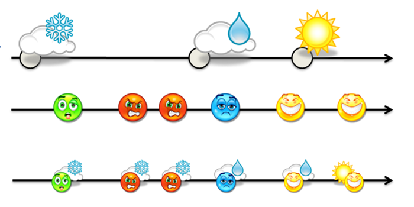

### Introduction

#### How weather influences the way we communicate on Twitter

Weather has long been regarded to impact everyday behavior. Spending time outdoors when it’s sunny is linked with a mood boost, that are casually referred to as “nice days”, whereas moods are lowered by cold and cloudy days, conditions that are generically classified as a “poor weather day”. However, studies on the relationship between weather and mood are limited, difficult to interpret, and have mixed result.

My project will be based on analysis of people’s mood variations on Twitter. Twitter can be an amazing open sourse for text and social web analyses. I’ll design R code for analyzing Twitter posts content via calculating the number of positive, negative and neutral words. My research will take place in New York City and compare “nice day” tweets to “poor weather day” tweets.

### Get The Data

Data collection:

- Get access to Twitter API
- Create code to retrive tweets for each day in New York City
- Create data_frame containing 3000 unique tweets for each date starting 12/03/17 to 12/09/17 at assigned coordinates
- Get past 7 days forecast

```r
december8_search<- searchTwitter("#newyork -filter:retweets",n=3000, since = "2017-12-08", until = "2017-12-09", geocode = "40.7128,-74.0060, 50mi")
```

There are certain limitations doing Twitter Analysis using R:

- Twitter API can only return past 7-10 days data
- Not every tweet has location assigned to it, so I had to add “#newyork”" as search keyword.

### Sentiment analysis

- Download list of negative and positive words. Availible here: https://github.com/jeffreybreen/twitter-sentiment-analysis-tutorial-201107/tree/master/data/opinion-lexicon-English
- Evaluate each tweet based on list of positive and negative words
- Create a table with count of negative and positive words per day

| X | score | text |
| --- | --- | --- |
| 1 | 2 | Did you know there is a connection between the #Christmas classic It's a Wonderful Life and #SenecaFalls #NewYork? https://t.co/COmKB6SLqJ |
| 2 | 2 | You can follow my updates on Facebook as well. Some nice photos https://t.co/DbKGTSHdO9 #Santorini #Vegas #paris https://t.co/VAVNNGK9tX |
| 3 | 0 | NY. #nyc #stpatricks #newyork #cousins @ St. Patrick's Cathedral https://t.co/LkaPDtqxVK |
| 4 | -1 | Expect Rangers to have bumpy ride on the road to playoffs https://t.co/5TEwfZWwch #NewsDay #NewYork #Sports #NewYorkCity #NYC #News |
| 5 | 1 | Samantha Prahalis now making Lauren Hansen and Ward Melville better https://t.co/wYIPeYjqDM #NewsDay #NewYork https://t.co/hCYwDWRFyj |
| 6 | 2 | Toronto FC wins first MLS cup title, defeats Seattle Sounders 2-0 https://t.co/Qpfsy422nN #NewsDay #NewYork #Sports #NewYorkCity #NYC #News |
| 7 | 1 | #NewYork Jets: 3 Reasons theyll defeat Broncos in Week 14 https://t.co/VUVRIpMn5y https://t.co/KIhnwkB5Pd |
| 8 | -2 | With #Alabama Senate Race Defined by Scandal, Policy Issues are Overlooked https://t.co/HjVEQvoHlj Via @NYTimesCC #NewYork #NYC #Life |
| 9 | 0 | Lady Liberty-New York City Floor Pillow by broadmeadow https://t.co/pUSoWGNHMG #homedecor #statueofliberty https://t.co/syiMFhQ4ec |
| 10 | 1 | When your #faith means this much. @danleytattoos @tattoowonderland #youbelongattattoowonderland #tattoowonderland https://t.co/FuACe1kzGs |

[output cut: 2990 more lines]

### Coding

```r
pos.words <- scan('https://raw.githubusercontent.com/Lidiia25/DATA607_final_project/master/positive-words.txt', what='character', comment.char=';')
 neg.words <-  scan('https://raw.githubusercontent.com/Lidiia25/DATA607_final_project/master/negative-words.txt', what='character', comment.char=';')
 score.sentiment <- function(sentences, pos.words, neg.words, .progress='none')
 {
 require(plyr)
 require(stringr)
 scores <- laply(sentences, function(sentence, pos.words, neg.words){
 sentence <- gsub('[[:punct:]]', "", sentence)
 sentence <- gsub('[[:cntrl:]]', "", sentence)
 sentence <- gsub('\\d+', "", sentence)
 sentence <- tolower(sentence)
 word.list <- str_split(sentence, '\\s+')
 words <- unlist(word.list)
 pos.matches <- match(words, pos.words)
 neg.matches <- match(words, neg.words)
 pos.matches <- !is.na(pos.matches)
 neg.matches <- !is.na(neg.matches)
 score <- sum(pos.matches) - sum(neg.matches)
 return(score)
 }, pos.words, neg.words, .progress=.progress)
 scores.df <- data.frame(score=scores, text=sentences)
 return(scores.df)
 }
 december$text <- as.factor(december$text)
december$text <- sapply(december$text,function(row) iconv(row, "latin1", "ASCII", sub=""))
december_sentiment <- score.sentiment(december$text, pos.words, neg.words, .progress='text')
december2 <- december_sentiment
december2$created <- december$created
december2$created <- as.Date(december2$created)
december3 <- mutate(december2, tweet=ifelse(december2$score > 0, 'positive', ifelse(december2$score < 0, 'negative', 'neutral')))
 december4 <- group_by(december3, tweet, created)
december4 <- summarise(december4, number=n())
dec_final <- subset(december4, tweet != "neutral")
```

### Results

| X | tweet | created | number |
| --- | --- | --- | --- |
| 1 | negative | 2017-12-03 | 361 |
| 2 | negative | 2017-12-04 | 261 |
| 3 | negative | 2017-12-05 | 260 |
| 4 | negative | 2017-12-06 | 278 |
| 5 | negative | 2017-12-07 | 230 |
| 6 | negative | 2017-12-08 | 256 |
| 7 | negative | 2017-12-09 | 265 |
| 8 | positive | 2017-12-03 | 947 |
| 9 | positive | 2017-12-04 | 1025 |
| 10 | positive | 2017-12-05 | 897 |

[output cut: 4 more lines]

### Visualizing

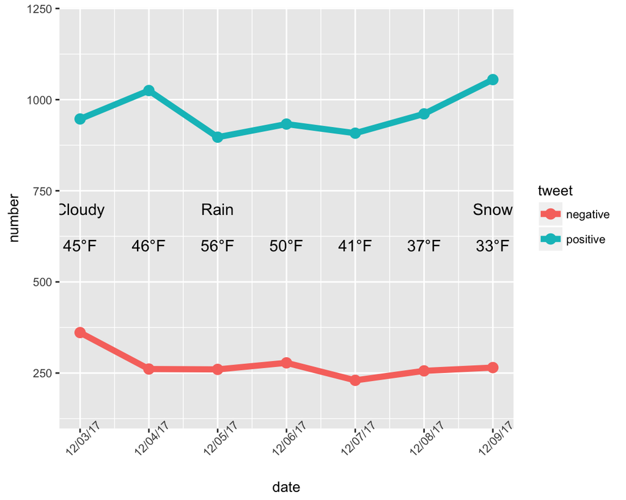

12/03/17 Cloudy and cold weather. There are increased number of negative tweets.

12/09/17 First snow day in NYC. There are increase number of positive tweets

### Conclusion

Twitter is an amazing tool that can track attitudes and feelings on the web on variety of subjects.

Twitter sentiment analysis tools enable businesses to:

- See what people are saying about the business’s brand on Twitter.
- Do market research on how people feel about competitors, market trends, product offerings etc.
- Analyze the impact of marketing campaigns on Twitter users.

With free tools for sentiment analysis, we can begin understanding how Twitter marketing efforts are performing without any investment. Additionally, we can begin monitoring Twitter for signs of problems (e.g., customer complaints about brand) as well as wins (e.g., things customers like about brand).

### References

https://developer.twitter.com/en/docs/tweets/filter-realtime/guides/basic-stream-parameters

https://github.com/jeffreybreen/twitter-sentiment-analysis-tutorial-201107/tree/master/data/opinion-lexicon-English

https://www.timeanddate.com/weather/usa/new-york/historic

https://www.slideshare.net/ajayohri/twitter-analysis-by-kaify-rais

http://ram-n.github.io/weatherData/

https://www.wunderground.com/history/airport/KNYC/2017/12/9/WeeklyHistory.html?req_city=New%20York&req_state=NY&req_statename=New%20York&reqdb.zip=10001&reqdb.magic=8&reqdb.wmo=99999

http://sites.psu.edu/siowfa14/2014/10/22/can-weather-affect-your-overall-mood/